# Typhoon Surigae (2026): Rapid Report

Lincole Jiang, Majd Abid, Lawrence Chillrud, G. Brooke Anderson, Robbie M. Parks

2026-10-23

## Summary

**Data status:** Provisional — not yet reanalyzed (PROVISIONAL)

*Typhoon Surigae* (2026) was active from 2026-09-23 06:00:00 to 2026-10-01 06:00:00 UTC. Based on IBTrACS data obtained 10/23/2026, 1,363,197 people experienced tropical cyclone-force (>= 17.49 m/s) winds and 0 people experienced hurricane-force (>= 32.90 m/s) winds across Japan. No areas experienced Category 5 winds.

Table 1: Population exposed by country and storm intensity

| Country | Population exposed (tropical cyclone-force) | Population exposed (hurricane-force) |
| --- | --- | --- |
| Japan | 1,363,197 | 0 |

When accounting for total population, the table below shows the percentage of each country’s population exposed.

Table 2: Percentage of total population exposed by country and storm intensity

| Country | % Population exposed (tropical cyclone-force) | % Population exposed (hurricane-force) |
| --- | --- | --- |
| Japan | 1.1 | 0 |

The spatial extent of the impacts is illustrated in Figure 1, which maps exposure by wind intensity threshold at the second administrative unit (ADM2) level along with the storm track of Surigae.

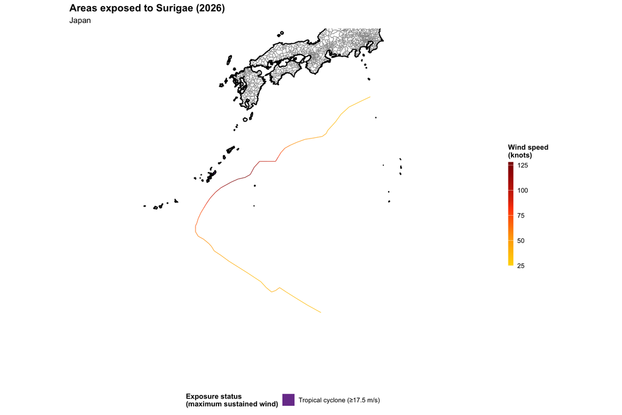

Figure 1: Spatial distribution of exposure

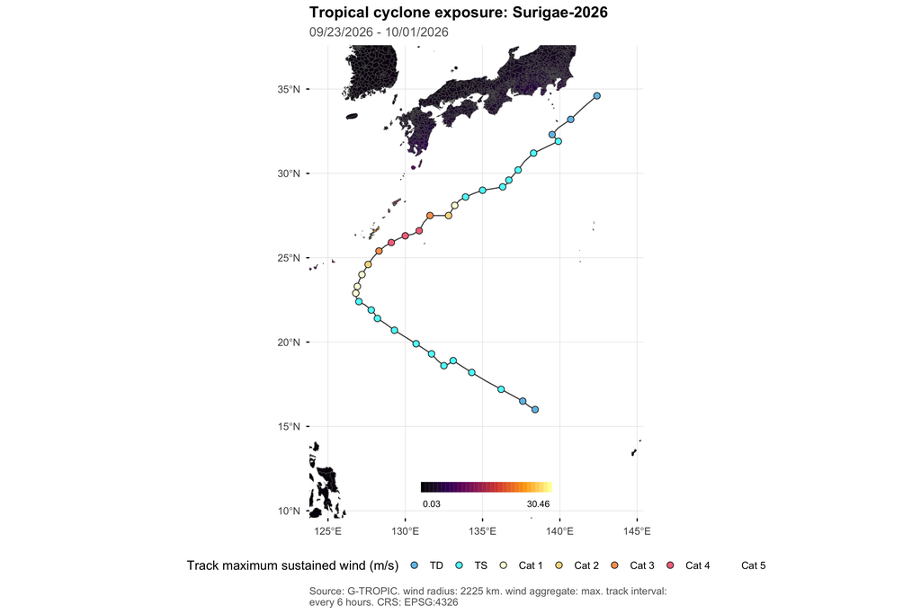

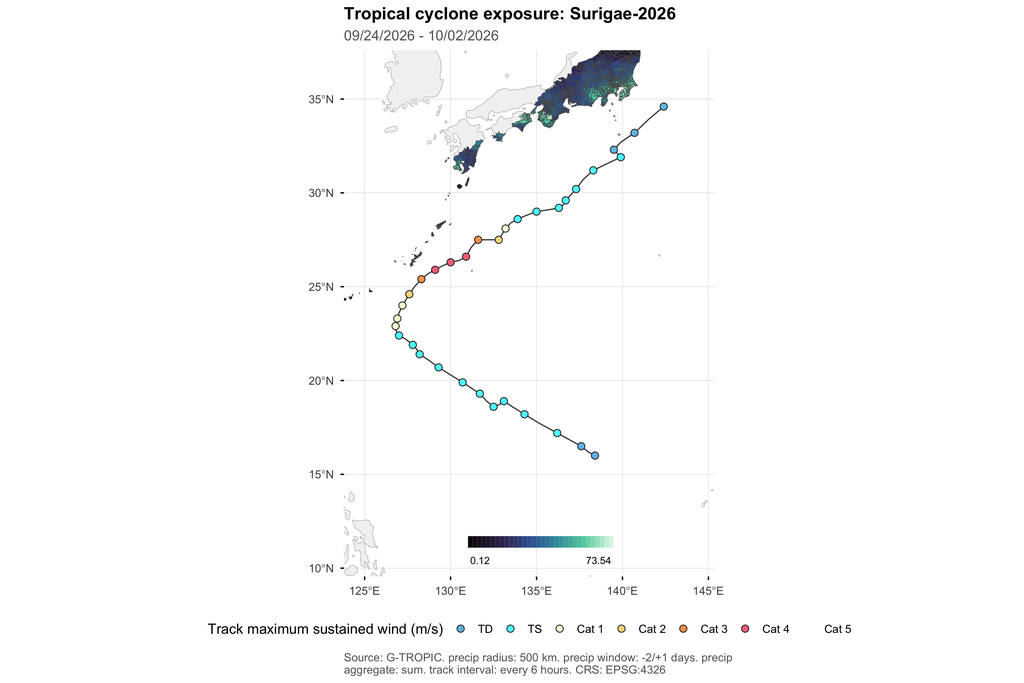

## Characterizing exposed areas

Figure 2 shows the distribution of relative deprivation (measured by population-weighted GRDI, aggregated to ADM2 level) and population for each exposed area, categorized by exposure status.

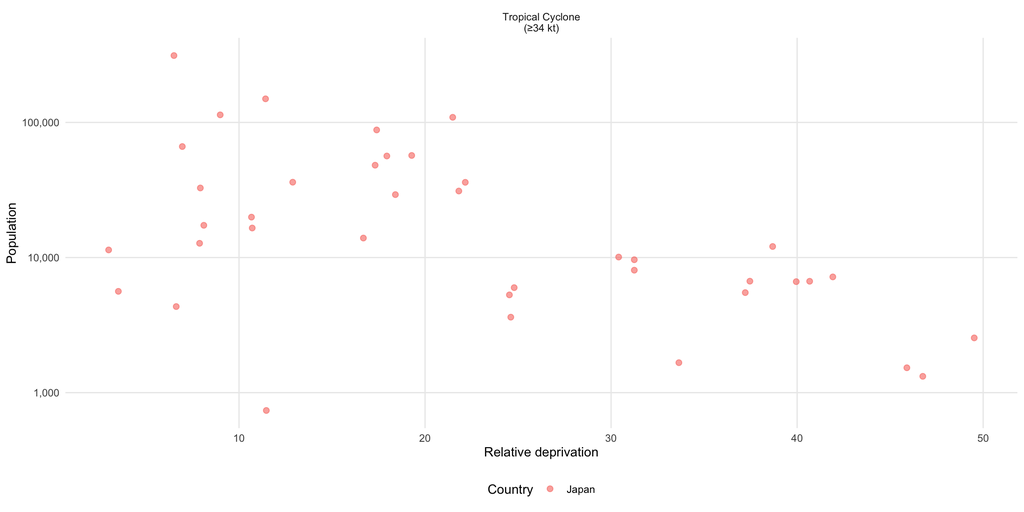

Figure 2: Socioeconomic and population distribution of exposed areas

Furthermore, we list the top areas affected (categorized by exposure status) with the most population:

|  | Area | Country | Population | Relative deprivation |
| --- | --- | --- | --- | --- |
| 1 | Naha | Japan | 312,568 | Low |
| 2 | Okinawa | Japan | 149,543 | Low |
| 3 | Urasoe | Japan | 113,789 | Low |
| 4 | Uruma | Japan | 109,125 | Moderately low |
| 5 | Ginowan | Japan | 87,995 | Low |
| 6 | Tomigusuku | Japan | 66,305 | Low |
| 7 | Nago | Japan | 56,958 | Moderately low |
| 8 | Nanjo | Japan | 56,436 | Low |
| 9 | Itoman | Japan | 48,249 | Low |
| 10 | Nishihara | Japan | 36,112 | Low |

[output cut: 29 more lines]

|  | Area | Country | Population | Relative deprivation |
| --- | --- | --- | --- | --- |

```
## *No areas experienced Category 5-force winds.*
```

- Note: GRDI relative deprivation values were classified into quartiles: 0–0.25 (low), 0.25–0.50 (moderately low), 0.50–0.75 (moderately high), 0.75–1.0 (high).